# Лабораторная работа 10. Случайный лес

Natalia Korskova

2016-05-02

### Вариант 8. Оливковые масла

Считываем данные и дорабатываем переменную с именем:

```r
olive <- read.table("olive.txt", header = TRUE, sep = c(","))
olive$name <- gsub('[0-9]+[.]', '', olive$name)
summary(olive)
```

```
##      name               region           area        palmitic
##  Length:572         Min.   :1.000   Min.   :1.0   Min.   : 610
##  Class :character   1st Qu.:1.000   1st Qu.:3.0   1st Qu.:1095
##  Mode  :character   Median :1.000   Median :3.0   Median :1201
##                     Mean   :1.699   Mean   :4.6   Mean   :1232
##                     3rd Qu.:3.000   3rd Qu.:7.0   3rd Qu.:1360
##                     Max.   :3.000   Max.   :9.0   Max.   :1753
##   palmitoleic        stearic          oleic         linoleic
##  Min.   : 15.00   Min.   :152.0   Min.   :6300   Min.   : 448.0
##  1st Qu.: 87.75   1st Qu.:205.0   1st Qu.:7000   1st Qu.: 770.8
##  Median :110.00   Median :223.0   Median :7302   Median :1030.0
##  Mean   :126.09   Mean   :228.9   Mean   :7312   Mean   : 980.5
##  3rd Qu.:169.25   3rd Qu.:249.0   3rd Qu.:7680   3rd Qu.:1180.8
##  Max.   :280.00   Max.   :375.0   Max.   :8410   Max.   :1470.0
##    linolenic       arachidic       eicosenoic
##  Min.   : 0.00   Min.   :  0.0   Min.   : 1.00
##  1st Qu.:26.00   1st Qu.: 50.0   1st Qu.: 2.00
##  Median :33.00   Median : 61.0   Median :17.00
##  Mean   :31.89   Mean   : 58.1   Mean   :16.28
##  3rd Qu.:40.25   3rd Qu.: 70.0   3rd Qu.:28.00
##  Max.   :74.00   Max.   :105.0   Max.   :58.00
```

Проверим пропорции отклика прежде чем разбивать выборку на тестовое и обучающее множество:

```r
table(as.factor(olive[, 2]))
```

```
##
##   1   2   3
## 323  98 151
```

Значение отклика несбалансировано по разным регионам. Хочется разбить первый регион примерно пополам. Посмотрим, какие области входят в первый регион, сколько в них наблюдений:

```r
unique(olive$name[olive$region == 1])
```

```
## [1] "North-Apulia" "Calabria"     "South-Apulia" "Sicily"
```

```r
tmp <- olive[, 1:2]
tmp <- tmp[tmp$region == 1, ]
table(tmp)
```

```
##               region
## name             1
##   Calabria      56
##   North-Apulia  25
##   Sicily        36
##   South-Apulia 206
```

Выделим Северную и Южную Апулию в отдельный регион. Кластеризация методом ближайших соседей показала несостоятельность такого отделения, поэтому позже посмотрим на работу алгоритма без отделения Апулии.

```r
olive_1 <- olive
olive_1$region[olive_1$name == "North-Apulia"] <- 4
olive_1$region[olive_1$name == "South-Apulia"] <- 4
table(as.factor(olive_1[, 2]))
```

```
##
##   1   2   3   4
##  92  98 151 231
```

Теперь данные более сбалансированные. В одной Южной Апулии больше наблюдений, чем в первом или втором регионе. Поскольку разбивать одну область (Южную Апулию) на две, когда областей не так уж много, представляется нелогичным, остановимся на этом.

Разобьём выборку на обучающее и тестовое множество в пропорции 2:1, оставив столбцы о содержании жирных кислот и регион:

```r
set.seed(31415)
test_num <- sample(1:nrow(olive_1), 191, replace = FALSE)
olive_1_train <- olive_1[-test_num, c(2, 4:11)]
olive_1_test <- olive_1[test_num, c(2, 4:11)]
```

Выделим предикторы и отклик:

```r
x_1_train <- olive_1_train[, 2:9]
y_1_train <- as.factor(olive_1_train[, 1])
x_1_test <- olive_1_test[, 2:9]
y_1_test <- as.factor(olive_1_test[, 1])
```

Запустим алгоритм классификации с помощью случайного леса, начав со 100 деревьев:

```r
library(randomForest)
ntree_1 <- 100
nodesize_1 <-1
keep.forest_1 <- TRUE

rf_1 <- randomForest(x = x_1_train, y = y_1_train,
                     ntree = ntree_1, mtry = floor(sqrt(ncol(olive_1))),replace = FALSE,
                     nodesize = nodesize_1, importance = TRUE, localImp = FALSE,
                     proximity = FALSE, norm.votes = TRUE, do.trace = ntree_1/10,
                     keep.forest = keep.forest_1, corr.bias = FALSE, keep.inbag = FALSE)
```

```
## ntree      OOB      1      2      3      4
##    10:   6.10% 17.74%  0.00%  0.00%  7.89%
##    20:   5.25% 17.46%  0.00%  0.00%  5.84%
##    30:   4.99% 14.29%  0.00%  0.00%  6.49%
##    40:   4.72% 14.29%  0.00%  0.00%  5.84%
##    50:   4.46% 14.29%  0.00%  0.00%  5.19%
##    60:   4.72% 12.70%  0.00%  0.00%  6.49%
##    70:   4.46% 14.29%  0.00%  0.00%  5.19%
##    80:   4.72% 14.29%  0.00%  0.00%  5.84%
##    90:   4.20% 11.11%  0.00%  0.00%  5.84%
##   100:   4.20% 12.70%  0.00%  0.00%  5.19%
```

Уже для 50 деревьев улучшать нечего, уменьшим число деревьев и посмотрим, какое количество деревьев до 50 может быть достаточным:

```r
set.seed(31415)
ntree_2 <- 50

rf_2 <- randomForest(x = x_1_train, y = y_1_train,
                     ntree = ntree_2, mtry = floor(sqrt(ncol(olive_1))),replace = FALSE,
                     nodesize = nodesize_1, importance = TRUE, localImp = FALSE,
                     proximity = FALSE, norm.votes = TRUE, do.trace = ntree_2/10,
                     keep.forest = keep.forest_1, corr.bias = FALSE, keep.inbag = FALSE)
```

```
## ntree      OOB      1      2      3      4
##     5:   6.07% 12.73%  1.69%  4.30%  6.47%
##    10:   5.00%  9.68%  3.08%  1.01%  6.49%
##    15:   5.25% 14.29%  1.54%  1.01%  5.84%
##    20:   4.72% 12.70%  0.00%  0.00%  6.49%
##    25:   5.25% 19.05%  0.00%  0.00%  5.19%
##    30:   4.99% 15.87%  0.00%  0.00%  5.84%
##    35:   4.99% 17.46%  0.00%  0.00%  5.19%
##    40:   4.20% 15.87%  0.00%  0.00%  3.90%
##    45:   4.72% 17.46%  0.00%  0.00%  4.55%
##    50:   4.46% 17.46%  0.00%  0.00%  3.90%
```

40 деревьев выглядят хорошим результатом.

```r
set.seed(31415)
ntree_3 <- 40

rf_3 <- randomForest(x = x_1_train, y = y_1_train,
                     ntree = ntree_3, mtry = floor(sqrt(ncol(olive_1))),replace = FALSE,
                     nodesize = nodesize_1, importance = TRUE, localImp = FALSE,
                     proximity = FALSE, norm.votes = TRUE, do.trace = ntree_3/10,
                     keep.forest = keep.forest_1, corr.bias = FALSE, keep.inbag = FALSE)
```

```
## ntree      OOB      1      2      3      4
##     4:   6.81% 13.46%  1.89%  3.53%  8.27%
##     8:   6.47% 15.25%  3.08%  1.03%  8.00%
##    12:   5.00% 12.90%  1.54%  1.01%  5.84%
##    16:   5.25% 14.29%  1.54%  0.00%  6.49%
##    20:   4.72% 12.70%  0.00%  0.00%  6.49%
##    24:   5.25% 17.46%  0.00%  0.00%  5.84%
##    28:   4.99% 15.87%  0.00%  0.00%  5.84%
##    32:   5.25% 17.46%  0.00%  0.00%  5.84%
##    36:   4.46% 15.87%  0.00%  0.00%  4.55%
##    40:   4.20% 15.87%  0.00%  0.00%  3.90%
```

Оценка качества для обучающего и тестового множеств:

```r
pred_1 <- predict(rf_3, x_1_train)
table(pred_1, y_1_train)
```

```
##       y_1_train
## pred_1   1   2   3   4
##      1  63   0   0   0
##      2   0  65   0   0
##      3   0   0  99   0
##      4   0   0   0 154
```

```r
pred_2 <- predict(rf_3, x_1_test)
table(pred_2, y_1_test)
```

```
##       y_1_test
## pred_2  1  2  3  4
##      1 26  0  0  2
##      2  0 33  0  0
##      3  0  0 52  0
##      4  3  0  0 75
```

Посмотрим работу случайного леса на исходном множестве, без отделения Апулии. Разиение на обучающее и тестовое множество по тем же индексам:

```r
olive_train <- olive[-test_num, c(2, 4:11)]
olive_test <- olive[test_num, c(2, 4:11)]
x_train <- olive_train[, 2:9]
y_train <- as.factor(olive_train[, 1])
x_test <- olive_test[, 2:9]
y_test <- as.factor(olive_test[, 1])
```

Начнём с 50 деревьев:

```r
set.seed(31415)
ntree_4 <- 50

rf_4 <- randomForest(x = x_train, y = y_train,
                     ntree = ntree_4, mtry = floor(sqrt(ncol(olive_1))),replace = FALSE,
                     nodesize = nodesize_1, importance = TRUE, localImp = FALSE,
                     proximity = FALSE, norm.votes = TRUE, do.trace = ntree_4/10,
                     keep.forest = keep.forest_1, corr.bias = FALSE, keep.inbag = FALSE)
```

```
## ntree      OOB      1      2      3
##     5:   1.49%  0.52%  3.64%  2.25%
##    10:   0.53%  0.47%  1.54%  0.00%
##    15:   0.26%  0.00%  0.00%  1.01%
##    20:   0.26%  0.46%  0.00%  0.00%
##    25:   0.00%  0.00%  0.00%  0.00%
##    30:   0.00%  0.00%  0.00%  0.00%
##    35:   0.00%  0.00%  0.00%  0.00%
##    40:   0.00%  0.00%  0.00%  0.00%
##    45:   0.00%  0.00%  0.00%  0.00%
##    50:   0.00%  0.00%  0.00%  0.00%
```

```r
set.seed(31415)
ntree_5 <- 20

rf_5 <- randomForest(x = x_train, y = y_train,
                     ntree = ntree_5, mtry = floor(sqrt(ncol(olive_1))),replace = FALSE,
                     nodesize = nodesize_1, importance = TRUE, localImp = FALSE,
                     proximity = FALSE, norm.votes = TRUE, do.trace = ntree_5/10,
                     keep.forest = keep.forest_1, corr.bias = FALSE, keep.inbag = FALSE)
```

```
## ntree      OOB      1      2      3
##     2:   1.77%  0.80%  2.56%  3.23%
##     4:   1.59%  0.55%  6.12%  1.19%
##     6:   1.14%  0.51%  1.64%  2.13%
##     8:   1.08%  0.48%  1.56%  2.06%
##    10:   0.53%  0.47%  1.54%  0.00%
##    12:   0.79%  0.93%  1.54%  0.00%
##    14:   0.26%  0.46%  0.00%  0.00%
##    16:   0.26%  0.00%  0.00%  1.01%
##    18:   0.00%  0.00%  0.00%  0.00%
##    20:   0.26%  0.46%  0.00%  0.00%
```

Оценка качества модели:

```r
pred_3 <- predict(rf_5, x_1_train)
table(pred_3, y_1_train)
```

```
##       y_1_train
## pred_3   1   2   3   4
##      1  63   0   0 154
##      2   0  65   0   0
##      3   0   0  99   0
```

```r
pred_4 <- predict(rf_5, x_1_test)
table(pred_4, y_1_test)
```

```
##       y_1_test
## pred_4  1  2  3  4
##      1 29  0  0 77
##      2  0 33  0  0
##      3  0  0 52  0
```

Случайный лес отработал без ошибок, наблюдения из метода ближайших соседей о том, что не стоит отделять Апулию в отдельный регион, подтвердились и этим методом.

Посмотрим на информативность переменных:

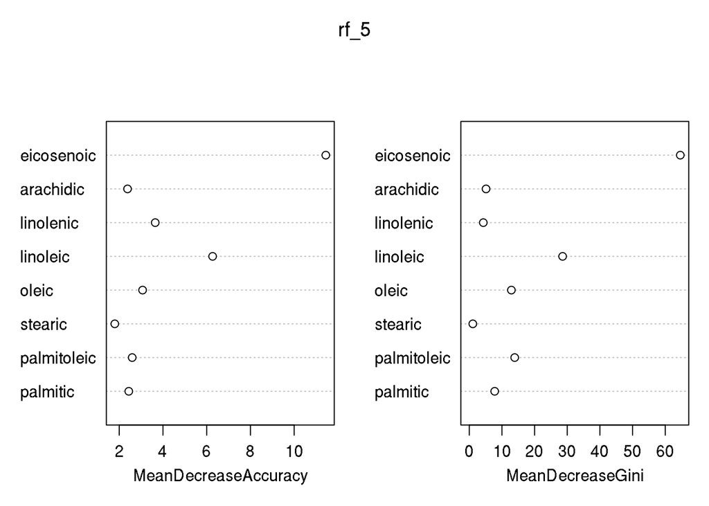

```r
varImpPlot(rf_5, sort = FALSE)
```

Самая информативня переменная ecosenoic – она же была первой переменной, по которой происходило разделение при использовании одного дерева. Следующая по информативности перменная linoleic.

Ранее неплохой результат показало отделение области Умбрии в отдельный регион. Посмотрим, как решающие деревья обработают такой набор данных:

```r
olive_2 <- olive
olive_2$region[olive_2$name == "Umbria"] <- 4
olive_2_train <- olive_2[-test_num, c(2, 4:11)]
olive_2_test <- olive_2[test_num, c(2, 4:11)]
```

Выделяем предикторы и отклик:

```r
x_2_train <- olive_2_train[, 2:9]
y_2_train <- as.factor(olive_2_train[, 1])
x_2_test <- olive_2_test[, 2:9]
y_2_test <- as.factor(olive_2_test[, 1])
```

Запускаем модель случайного леса из 50 деревьев:

```r
set.seed(31415)
ntree_6 <- 50

rf_6 <- randomForest(x = x_2_train, y = y_2_train,
                     ntree = ntree_6, mtry = floor(sqrt(ncol(olive_1))),replace = FALSE,
                     nodesize = nodesize_1, importance = TRUE, localImp = FALSE,
                     proximity = FALSE, norm.votes = TRUE, do.trace = ntree_6/10,
                     keep.forest = keep.forest_1, corr.bias = FALSE, keep.inbag = FALSE)
```

```
## ntree      OOB      1      2      3      4
##     5:   3.77%  3.57%  3.33%  3.51%  6.25%
##    10:   2.12%  1.40%  3.08%  4.92%  0.00%
##    15:   0.79%  0.46%  0.00%  1.61%  2.70%
##    20:   0.26%  0.00%  0.00%  1.61%  0.00%
##    25:   0.26%  0.00%  0.00%  1.61%  0.00%
##    30:   0.26%  0.00%  0.00%  1.61%  0.00%
##    35:   0.26%  0.00%  0.00%  1.61%  0.00%
##    40:   0.26%  0.00%  0.00%  1.61%  0.00%
##    45:   0.26%  0.00%  0.00%  1.61%  0.00%
##    50:   0.26%  0.00%  0.00%  1.61%  0.00%
```

Хорошее качество при 30 деревьях, это количество и оставим:

```r
set.seed(31415)
ntree_7 <- 30

rf_7 <- randomForest(x = x_2_train, y = y_2_train,
                     ntree = ntree_7, mtry = floor(sqrt(ncol(olive_1))),replace = FALSE,
                     nodesize = nodesize_1, importance = TRUE, localImp = FALSE,
                     proximity = FALSE, norm.votes = TRUE, do.trace = ntree_7/10,
                     keep.forest = keep.forest_1, corr.bias = FALSE, keep.inbag = FALSE)
```

```
## ntree      OOB      1      2      3      4
##     3:   3.82%  3.73%  1.96%  4.17%  7.14%
##     6:   4.19%  2.46%  4.84%  8.62%  5.71%
##     9:   2.39%  1.87%  3.12%  4.92%  0.00%
##    12:   0.79%  0.92%  0.00%  1.61%  0.00%
##    15:   0.79%  0.46%  0.00%  1.61%  2.70%
##    18:   0.52%  0.00%  0.00%  3.23%  0.00%
##    21:   0.26%  0.00%  0.00%  1.61%  0.00%
##    24:   0.26%  0.00%  0.00%  1.61%  0.00%
##    27:   0.26%  0.00%  0.00%  1.61%  0.00%
##    30:   0.26%  0.00%  0.00%  1.61%  0.00%
```

Оценка качества:

```r
pred_5 <- predict(rf_7, x_2_train)
table(pred_5, y_2_train)
```

```
##       y_2_train
## pred_5   1   2   3   4
##      1 217   0   0   0
##      2   0  65   0   0
##      3   0   0  62   0
##      4   0   0   0  37
```

```r
pred_6 <- predict(rf_7, x_2_test)
table(pred_6, y_2_test)
```

```
##       y_2_test
## pred_6   1   2   3   4
##      1 106   0   0   0
##      2   0  33   0   0
##      3   0   0  38   0
##      4   0   0   0  14
```

Ошибок нет – модель с отделением Умбрии в отдельный регион хорошо работает.

Информативность переменных:

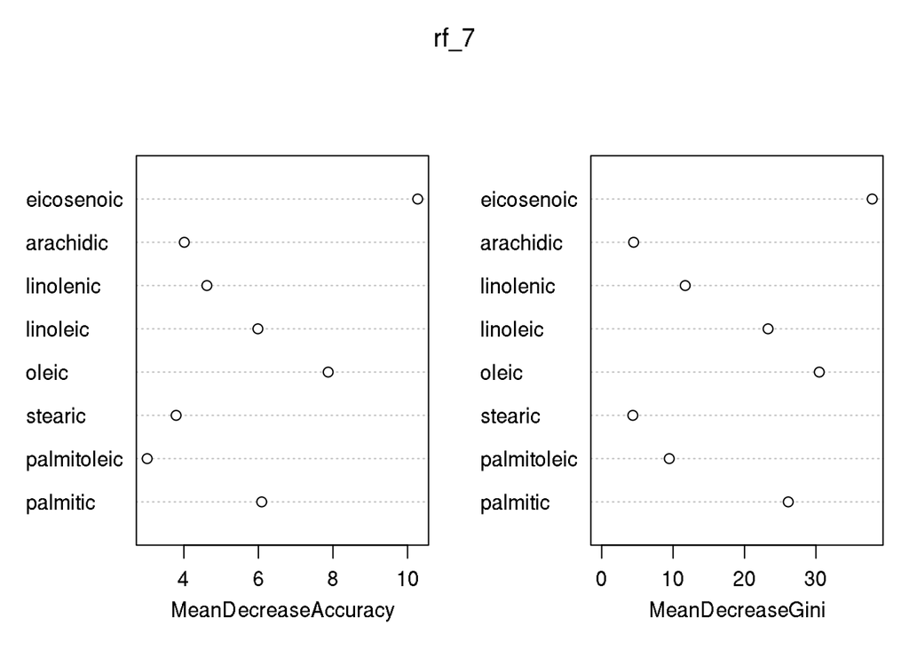

```r
varImpPlot(rf_7, sort = FALSE)
```

По-прежнему самой информативности переменной является ecosenoic, вторая по информативности oleic, что согласуется с работой одного решающего дерева.